# Sleep-Quality

Savaira Manoa

Adrian Pouflis

Eduard Vargas

2024-06-01

#### Section 1: Loading the libraries

#### Overall Research Question:

What is the impact of various lifestyle choices on sleep quality among adults?

#### Introduction to the data set.

The data set utilized for this work was obtained from Kaggle, a website and collection of services for data science, including dataset hosting. The data set license is under the Authors, listed as ‘Equilibrium’, but the data’s source was not available. Regardless, the data set is highly rated and widely used for academic purposes.

#### Data Set Introduction:

The following are the variables identified in the data set.

```
##  [1] "ID"                     "Age"                    "Gender"
##  [4] "Bedtime"                "Wakeup.time"            "Sleep.duration"
##  [7] "Sleep.efficiency"       "REM.sleep.percentage"   "Deep.sleep.percentage"
## [10] "Light.sleep.percentage" "Awakenings"             "Caffeine.consumption"
## [13] "Alcohol.consumption"    "Smoking.status"         "Exercise.frequency"
```

As the intention of this collaborative project is to answer the question of : *“What is the impact of various lifestyle choices on sleep quality among adults?”*, we will determine and analyse how a select few key variables impact sleep quality.

**Explanation of the Raw Data:**

```
## 'data.frame':    452 obs. of  15 variables:
##  $ ID                    : int  1 2 3 4 5 6 7 8 9 10 ...
##  $ Age                   : int  65 69 40 40 57 36 27 53 41 11 ...
##  $ Gender                : chr  "Female" "Male" "Female" "Female" ...
##  $ Bedtime               : chr  "2021-03-06 01:00:00" "2021-12-05 02:00:00" "2021-05-25 21:30:00" "2021-11-03 02:30:00" ...
##  $ Wakeup.time           : chr  "2021-03-06 07:00:00" "2021-12-05 09:00:00" "2021-05-25 05:30:00" "2021-11-03 08:30:00" ...
##  $ Sleep.duration        : num  6 7 8 6 8 7.5 6 10 6 9 ...
##  $ Sleep.efficiency      : num  0.88 0.66 0.89 0.51 0.76 0.9 0.54 0.9 0.79 0.55 ...
##  $ REM.sleep.percentage  : int  18 19 20 23 27 23 28 28 28 18 ...
##  $ Deep.sleep.percentage : int  70 28 70 25 55 60 25 52 55 37 ...
##  $ Light.sleep.percentage: int  12 53 10 52 18 17 47 20 17 45 ...
##  $ Awakenings            : num  0 3 1 3 3 0 2 0 3 4 ...
##  $ Caffeine.consumption  : num  0 0 0 50 0 NA 50 50 50 0 ...
##  $ Alcohol.consumption   : num  0 3 0 5 3 0 0 0 0 0 ...
##  $ Smoking.status        : chr  "Yes" "Yes" "No" "Yes" ...
##  $ Exercise.frequency    : num  3 3 3 1 3 1 1 3 1 0 ...
## NULL
```

```
##        ID             Age           Gender            Bedtime
##  Min.   :  1.0   Min.   : 9.00   Length:452         Length:452
##  1st Qu.:113.8   1st Qu.:29.00   Class :character   Class :character
##  Median :226.5   Median :40.00   Mode  :character   Mode  :character
##  Mean   :226.5   Mean   :40.29
##  3rd Qu.:339.2   3rd Qu.:52.00
##  Max.   :452.0   Max.   :69.00
##
##  Wakeup.time        Sleep.duration   Sleep.efficiency REM.sleep.percentage
##  Length:452         Min.   : 5.000   Min.   :0.5000   Min.   :15.00
##  Class :character   1st Qu.: 7.000   1st Qu.:0.6975   1st Qu.:20.00
##  Mode  :character   Median : 7.500   Median :0.8200   Median :22.00
##                     Mean   : 7.466   Mean   :0.7889   Mean   :22.62
##                     3rd Qu.: 8.000   3rd Qu.:0.9000   3rd Qu.:25.00
##                     Max.   :10.000   Max.   :0.9900   Max.   :30.00
##
##  Deep.sleep.percentage Light.sleep.percentage   Awakenings
##  Min.   :18.00         Min.   : 7.00          Min.   :0.000
##  1st Qu.:48.25         1st Qu.:15.00          1st Qu.:1.000
##  Median :58.00         Median :18.00          Median :1.000
##  Mean   :52.82         Mean   :24.56          Mean   :1.641
##  3rd Qu.:63.00         3rd Qu.:32.50          3rd Qu.:3.000
##  Max.   :75.00         Max.   :63.00          Max.   :4.000
##                                               NA's   :20
##  Caffeine.consumption Alcohol.consumption Smoking.status     Exercise.frequency
##  Min.   :  0.00       Min.   :0.000       Length:452         Min.   :0.000
##  1st Qu.:  0.00       1st Qu.:0.000       Class :character   1st Qu.:0.000
##  Median : 25.00       Median :0.000       Mode  :character   Median :2.000
##  Mean   : 23.65       Mean   :1.174                          Mean   :1.791
##  3rd Qu.: 50.00       3rd Qu.:2.000                          3rd Qu.:3.000
##  Max.   :200.00       Max.   :5.000                          Max.   :5.000
##  NA's   :25           NA's   :14                             NA's   :6
```

- **Analysis of the data encountered:**

The data set provides comprehensive information on sleep quality and related factors for 452 individuals. The data set includes demographic information such as age (9-69 years), and gender. Detailed sleep metrics recorded include bedtime, waketime, total sleep duration, number of awakenings during the night and sleep efficiency. Additionally, the dataset measures the percentage of sleep spent in different stages: REM, deep, and light sleep. The “Sleep efficiency” feature is a measure of the proportion of time spent asleep in bed.

Beyond sleep-specific data, the dataset captures lifestyle factors that influence sleep quality. These factors include caffeine/alcohol consumption, smoking status, and exercise frequency. Overall, this dataset is well-suited for investigating the relationships between sleep quality and various demographic and lifestyle factors, offering insights into how behaviors and characteristics impact sleep patterns and efficiency.

The table above summarises important information about the variables.

### Gender Sleep Efficiency, Sleep Duration and excercise Frequency variables: – By Eduard Vargas

**Research Questions:**

1. What is the level of exercise levels presented by gender and what is the impact of it in the sleeping quality?
2. Is there a bias or preference for each gender when talking about the exercise levels (times per week exercise is done)? if so, what is it for each gender?

In order to understand the data a sleeping efficiency, which was defined by the author as *“A measure of the proportion of time spent in bed that is actually spent asleep.”*, I decided to use a simple linear regression model in order to find the relationships between the habits of an adult person, and the consequences on the mentioned sleeping efficiency.

Here, the intercept, or dependent variable will be “Sleep Efficiency”:

```
##
## Call:
## lm(formula = Sleep.efficiency ~ Age + Caffeine.consumption +
##     Alcohol.consumption + Exercise.frequency + Gender, data = cleaned_data)
##
## Residuals:
##      Min       1Q   Median       3Q      Max
## -0.32074 -0.07276  0.01985  0.07990  0.27445
##
## Coefficients:
##                        Estimate Std. Error t value Pr(>|t|)
## (Intercept)           0.7184739  0.0221180  32.484  < 2e-16 ***
## Age                   0.0016640  0.0004670   3.563 0.000413 ***
## Caffeine.consumption  0.0002822  0.0002164   1.304 0.193129
## Alcohol.consumption  -0.0336521  0.0037310  -9.020  < 2e-16 ***
## Exercise.frequency    0.0261673  0.0042395   6.172 1.72e-09 ***
## GenderMale           -0.0219210  0.0130756  -1.676 0.094462 .
## ---
## Signif. codes:  0 '***' 0.001 '**' 0.01 '*' 0.05 '.' 0.1 ' ' 1
##
## Residual standard error: 0.1176 on 382 degrees of freedom
## Multiple R-squared:  0.2584, Adjusted R-squared:  0.2487
## F-statistic: 26.62 on 5 and 382 DF,  p-value: < 2.2e-16
```

**Observations:**

The linear model analysis reveals several significant relationships between the predictors and sleep efficiency. The model explains about 25.84% of the variability in sleep efficiency (R-squared = 0.2584). Key predictors such as age, alcohol consumption, and exercise frequency have significant effects on sleep efficiency, while caffeine consumption is not a significant predictor. The intercept indicates the baseline sleep efficiency when all predictors are at zero, and the overall model is statistically significant (p-value < 2.2e-16).

**Highlights:**

- Gender: Coefficient for Gender (Male): -0.0219210 Interpretation: On average, males have a sleep efficiency that is approximately 2.19% lower than females, although this effect is only marginally significant (p = 0.094462). Significance: The marginal significance suggests that while there is a difference in sleep efficiency between genders, it is not as strongly supported by the data compared to other predictors.
- Exercise Frequency Coefficient for Exercise Frequency: 0.0261673

**Interpretation:** Each additional day of exercise per week is associated with a 2.62% increase in sleep efficiency, holding other factors constant.

**Significance:** This relationship is highly significant (p = 1.72e-09), indicating a strong positive impact of exercise on sleep efficiency.

In summary, the linear model highlights that while gender has a marginal impact on sleep efficiency, exercise frequency has a robust positive effect. These insights can inform strategies to improve sleep quality, particularly emphasizing the benefits of regular exercise.

After understanding the relevant variables that affect the “Sleeping Efficiency” it is important to visualize how the current information is, and then proceed to work on more relationships with the help of the model elaborated:

First of all, it is important to understand what are the exercise, sleep efficiencies and Duration levels per gender:

(#tab:Printint the tables)Summary of Sleep Efficiency by Gender

| Gender | Min_Sleep_Efficiency | Max_Sleep_Efficiency | Average_Sleep_Efficiency | Average_exercise_levels |
| --- | --- | --- | --- | --- |
| Female | 0.5 | 0.98 | 0.79 | 1.43 |
| Male | 0.5 | 0.99 | 0.78 | 2.08 |

(#tab:sleep duration by gender)Summary of Sleep Duration and Exercise Levels by Gender

| Gender | Min_Sleep_Duration | Max_Sleep_Duration | Average_Duration | Average_exercise_levels |
| --- | --- | --- | --- | --- |
| **Gender Summary** |  |  |  |  |
| Female | 5 | 10 | 7.49 | 1.43 |
| Male | 5 | 10 | 7.40 | 2.08 |

In the following section, I will plot and visualize the relationships between exercise frequency, duration and sleep efficiency. To identify possible trends in sleep efficiency levels, in order to examine the distribution, I will make use of histogram and scatter plots. These visualizations will help in understanding how exercise frequency influences sleep efficiency and whether consistent patterns emerge across different levels of physical activity.

#### Sleep Efficiency and Exercise Frequency per Gender:

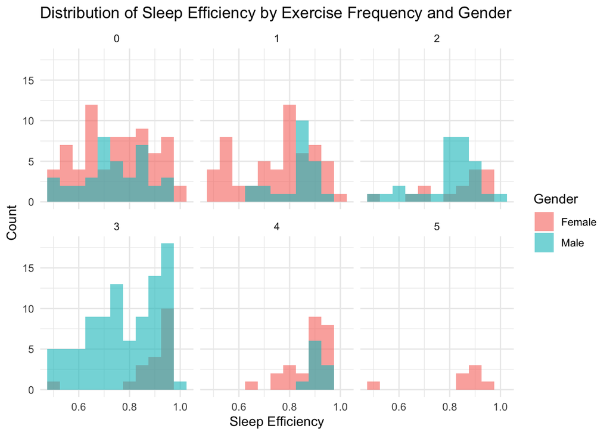

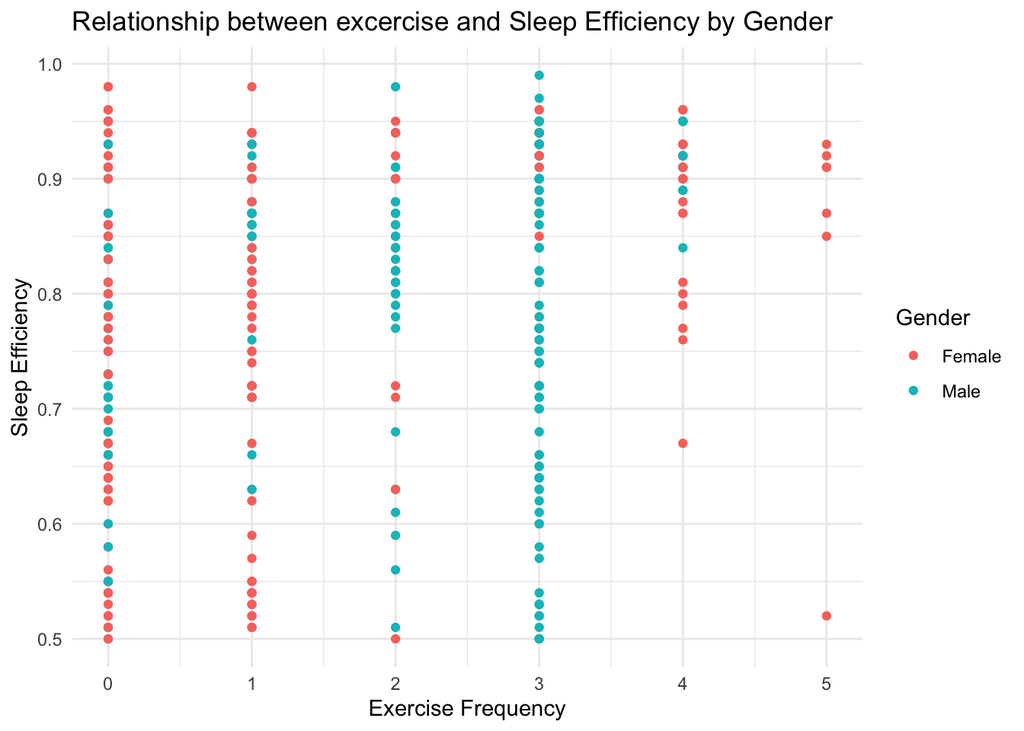

Both the dot plot and the histogram display the distribution of sleep efficiency by exercise frequency and gender, revealing several important observations:

1. The distribution of sleep efficiency shows that many individuals achieve values close to 1.0, indicating high sleep efficiency for a significant portion of the population. There is a positive relationship between exercise frequency and sleep efficiency, particularly at 3 and 5 days per week, suggesting regular exercise enhances sleep efficiency.
2. For non-exercisers (0 days), both genders show a wide range of sleep efficiencies. As exercise frequency increases to 1 and 2 days, more individuals achieve sleep efficiencies around 0.8 to 1.0. Those exercising 3 days per week exhibit a peak in high sleep efficiency, especially males. This trend continues for 4 and 5 days of exercise, despite fewer participants.
3. Both genders show higher sleep efficiency with increased exercise. Females maintain high sleep efficiency with a more even distribution across exercise levels, while males show a stronger concentration at higher sleep efficiencies, particularly with more frequent exercise. Regular exercise at moderate to high levels (3-5 days a week) is linked to better sleep efficiency for both genders, highlighting the benefits of physical activity on sleep quality.

#### Sleep Duration, Efficiency and the relationship with Exercise Frequency per Gender:

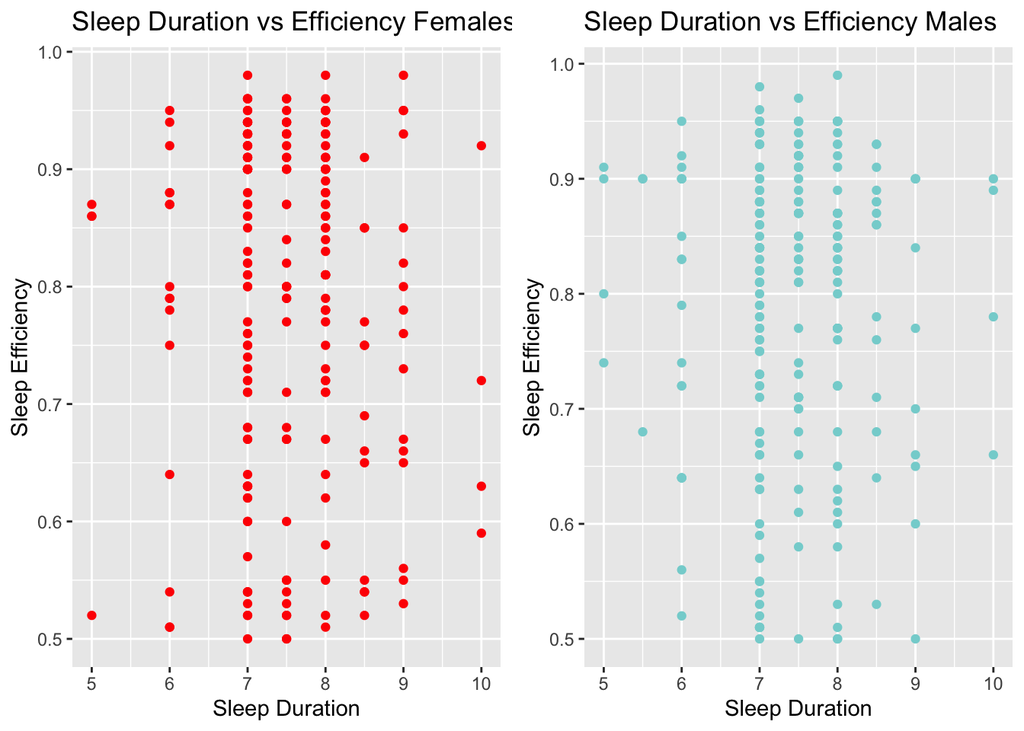

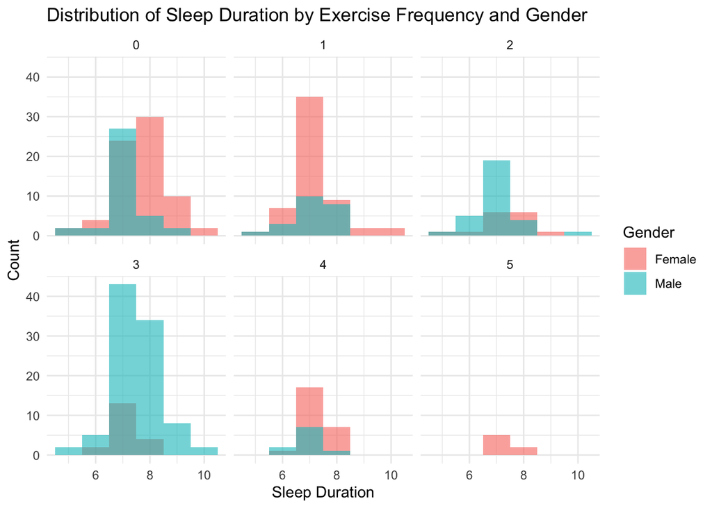

**Observations on the plots:**

Overall, the data suggests both genders maintain high sleep efficiency with consistent sleep durations of 7 to 8 hours, regardless of exercise frequency. Regular exercise enhances sleep quality, emphasizing the importance of consistent sleep duration.

#### General conclusions of the section:

The analysis of sleep efficiency in relation to exercise frequency and gender reveals that a significant portion of the population enjoys high sleep efficiency, particularly as exercise frequency increases. Many individuals exhibit sleep efficiencies closer to 1.0, especially at frequencies of 3 and 5 days per week. This trend implies that regular exercise contributes to better sleep efficiency, reinforcing the benefits of physical activity on sleep quality. Notably, individuals who exercise more frequently tend to maintain higher sleep efficiency, highlighting the importance of an active lifestyle for achieving optimal sleep.

Further examination reveals distinct patterns based on gender and exercise frequency. Both males and females show higher sleep efficiency with increased exercise, although the distribution patterns vary. Females tend to have a more evenly spread distribution across different exercise levels, while males display a stronger concentration of higher sleep efficiencies, particularly at higher exercise frequencies. Regardless of exercise frequency, both genders exhibit a consistent sleep duration, predominantly around 7 to 8 hours. This suggests that exercise enhances sleep efficiency within this range without significantly altering the preferred sleep duration.

### Age-generation and exercise analysis by *Savaira Manoa*

This section will focus on answering two questions involving sleep efficiency using the two variables, age grouped by generation and exercise frequency.

**Research Questions**

1. Some sleep studies have shown that sleep efficiency differs between age groups. What are these differences within the dataset chosen for this study and are there any specific ‘generations’ that show generally better levels of sleep efficiency compared to others?
2. Given the sleep efficiency data by generation discussed in question 1, and looking at specific life-style choices such as ensuring one exercises regularly, are levels of sleep efficiency still low amongst certain age groups and why?

**Analysis - Question 1: Sleep efficiency by age generation**

Sleep efficiency studies for specific age groups, have documented sleep efficiency for the aged (Desjardins et al.,2019) or sleep efficiency studies by lifespan (Kocevska et al., 2021).

This subsection will first look at sleep efficiency using age grouped by generation. Using the generational age groupings (Library of Congress, n.d.) ages of subjects were catgorised. Generation Alpha shows results for 9-11 years, Generation Z for 12-26 years, Millenial for 27-42 years, Generation X for 43-58 years and the Baby Boomers for 59-69 years.

Table 1: Summary of sleep efficiency by age generation

| ~ | Min_Sleep_Efficiency | Max_Sleep_Efficiency | Mean_Sleep_Efficiency |
| --- | --- | --- | --- |
| **Generation** |  |  |  |
| Gen_Alpha | 0.5200 | 0.56 | 0.5425000 |
| Gen_Z | 0.5000 | 0.95 | 0.7473333 |
| Millenial | 0.5000 | 0.98 | 0.8014074 |
| Gen_X | 0.5000 | 0.99 | 0.8143262 |
| Boomers | 0.5200 | 0.98 | 0.7575758 |
| **Percentile** |  |  |  |
| percentile_10 | 0.5260 | 0.64 | 0.5740000 |
| percentile_25 | 0.5350 | 0.74 | 0.6560000 |
| percentile_50 | 0.5450 | 0.85 | 0.7490000 |
| percentile_75 | 0.5525 | 0.92 | 0.8275000 |
| percentile_90 | 0.5570 | 0.94 | 0.8566000 |

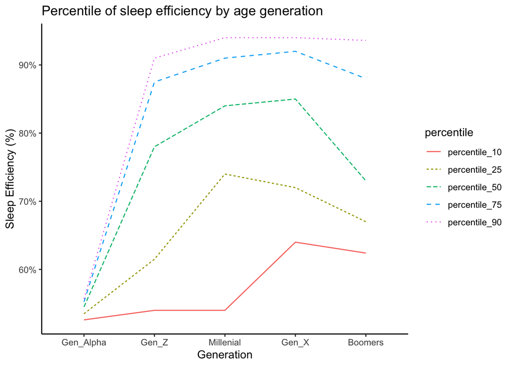

We explore this further in the Figure above. The Figure shows the percentiles of each generation for sleep efficiency. When read in conjunction with the table above, Generation Alpha has sleep efficiency in the lower 50% of the population. On average, the Baby Boomers have 0.75 sleep efficency which represents approximately 50% of their population within the dataset, Generation X has 0.81 sleep efficiency which represents approximately less than 50% of their population, the Millenials has 0.80 sleep efficiency which also represents less than 50% of their population, and Generation Z has 0.74 sleep efficiency representing less than 50% of their population. Therefore, on average Generation X have the highest sleep efficiency, but this represents less than half of their population.

**Analysis - Question 2: Sleep efficiency by exercise frequency**

This subsection analyses sleep efficiency by exercise frequency, taking into account the generation of each individual in the dataset.

Table 2: Summary of sleep efficiency by exercise frequency

| Freq_or_Percentile | Min_Sleep_Efficiency | Max_Sleep_Efficiency | Mean_Sleep_Efficiency |
| --- | --- | --- | --- |
| **Frequency** |  |  |  |
| Low | 0.50 | 0.980 | 0.7573936 |
| Medium | 0.50 | 0.990 | 0.8023418 |
| High | 0.52 | 0.960 | 0.8826190 |
| **Percentile** |  |  |  |
| percentile_10 | 0.54 | 0.791 | 0.6426667 |
| percentile_25 | 0.66 | 0.870 | 0.7500000 |
| percentile_50 | 0.78 | 0.910 | 0.8433333 |
| percentile_75 | 0.87 | 0.930 | 0.9058333 |
| percentile_90 | 0.93 | 0.950 | 0.9400000 |

The table above shows sleep efficiency by the three chosen frequencies of exercise: low represents nil or 1 frequency, medium represents 2 or 3 and high greater than 3. Sleep efficiency on average is higher with high exercise. Exploring this further by generation, we look at the table above together with the Figure below.

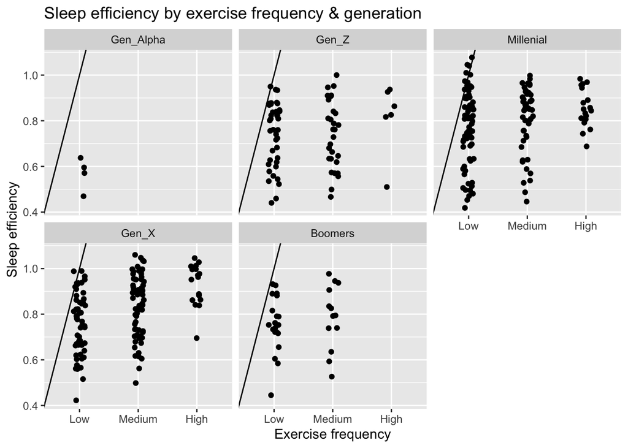

The Figure above shows by generation, which exercise frequencies are more or less popular. Generation Alpha is the standout with low exercise which explains their low sleep efficiency, but may also be due to a lower sample number. Generation X shows a majority of medium exercise frequency which explains the higher sleep efficiency. The results for Millennials curiously show a clustering of over 0.8 sleep efficiency even with low exercise, which is above the average of 0.75. This may be due to other lifestyle factors and a more resilient age.

**Conclusion** In the Age Generation by Exercise analysis section by Savaira, we found that Generation Alpha has the least sleep efficiency, while Generation X on average have the highest sleep efficiency. This was also inline with the results for exercise frequency, where Generation Alpha is the standout with low exercise and low sleep efficiency and Generation X showing a majority of medium exercise corresponding to higher sleep efficiency. Curiously, Millennials show a clustering of above average 0.8 sleep efficiency even with low exercise, which may be due to other lifestyle factors and a more resilient age.

### Age and alcohol consumption analysis:

- Adrian Pouflis

**Research Question**

As identified earlier using regression, age and alcohol consumption have significant impacts on sleep efficiency. Alcohol consumption had a significantly larger magnitude of impact than age, its direction was negative.

I have two research questions:

1:How do these variables impact quality of sleep independently?

2:How do these variables interact? Does one variable impact the magnitude of (moderate) the effect of the other?

**Analysis - Question 1**

These effects are small, as was noted already, the linear regression explains only about 25.84% of the variance in sleep efficiency. Below the regression is performed on different sleep measures, to similar results.

```
##
## The r-squared value for the linear model on sleep duration is 0.01159178
```

```
##
## The r-squared value for the linear model on number of awakenings is 0.1226739
```

I examined directly the relationship between age/alcohol consumption and sleep efficiency.

| Alcohol.consumption | Mean_Sleep_Efficiency |
| --- | --- |
| 0 | 0.8323982 |
| 1 | 0.8034043 |
| 2 | 0.6691429 |
| 3 | 0.7612821 |
| 4 | 0.6884211 |
| 5 | 0.6785185 |

The relationship between alcohol and sleep efficiency is uncertain, lower doses of alcohol see higher efficiency, but the value spikes at dose 3.

I both tabled age bands and charted age against efficiency:

| Age_bands | Sleep.efficiency |
| --- | --- |
| [9,14] | 0.5583333 |
| (14,19] | 0.7260000 |
| (19,24] | 0.7473333 |
| (24,29] | 0.7650000 |
| (29,34] | 0.8105405 |
| (34,39] | 0.8217500 |
| (39,44] | 0.7930233 |
| (44,49] | 0.8448837 |
| (49,54] | 0.8080000 |
| (54,59] | 0.7894286 |
| (59,64] | 0.7583333 |
| (64,69] | 0.7566667 |

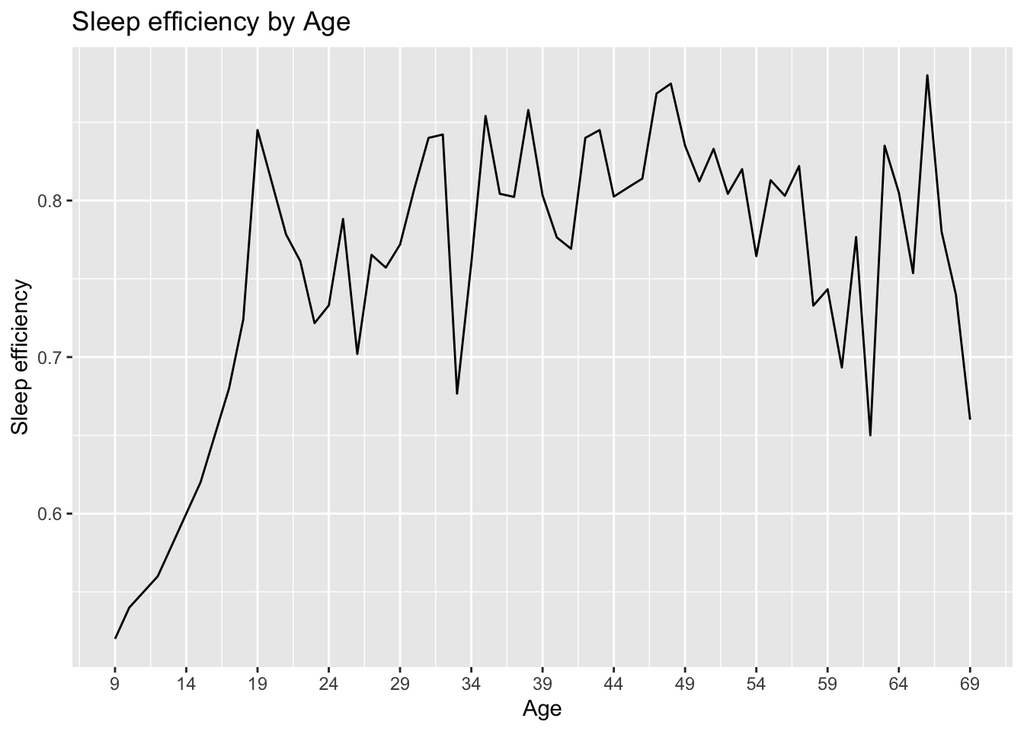

Sleep efficiency appears to peak from 29-59.

**Analysis - Question 2**

Next is to determine if and how these variables interact.

I first chart these variables against each other to see if they interact directly.

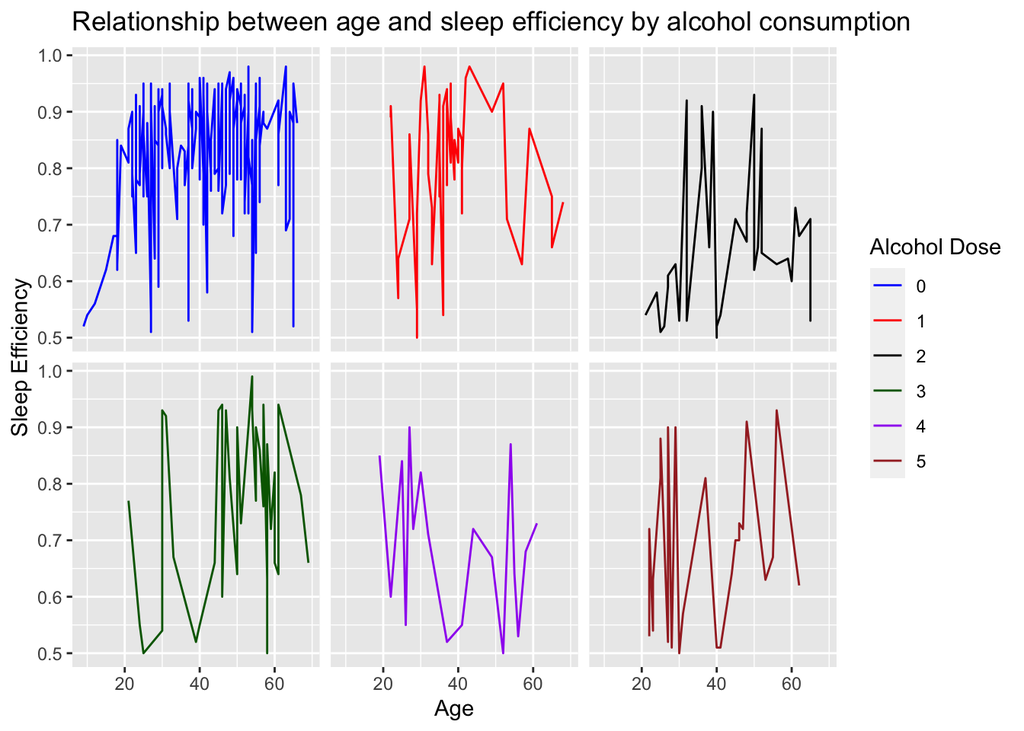

These graphs are erratic and show no clear pattern.

Next, I will use moderation analysis, a variant on the linear regression already performed.

```
##
## Call:
## lm(formula = Sleep.efficiency ~ Age + Caffeine.consumption +
##     Alcohol.consumption + Exercise.frequency + Gender + Age *
##     Alcohol.consumption, data = cleaned_data)
##
## Residuals:
##      Min       1Q   Median       3Q      Max
## -0.32843 -0.07570  0.02072  0.07882  0.26453
##
## Coefficients:
##                           Estimate Std. Error t value Pr(>|t|)
## (Intercept)              0.7094532  0.0253501  27.986  < 2e-16 ***
## Age                      0.0019174  0.0005822   3.293  0.00108 **
## Caffeine.consumption     0.0002870  0.0002167   1.325  0.18605
## Alcohol.consumption     -0.0253548  0.0119679  -2.119  0.03477 *
## Exercise.frequency       0.0259268  0.0042549   6.093 2.71e-09 ***
## GenderMale              -0.0231868  0.0131981  -1.757  0.07975 .
## Age:Alcohol.consumption -0.0002048  0.0002806  -0.730  0.46602
## ---
## Signif. codes:  0 '***' 0.001 '**' 0.01 '*' 0.05 '.' 0.1 ' ' 1
##
## Residual standard error: 0.1177 on 381 degrees of freedom
## Multiple R-squared:  0.2594, Adjusted R-squared:  0.2477
## F-statistic: 22.24 on 6 and 381 DF,  p-value: < 2.2e-16
```

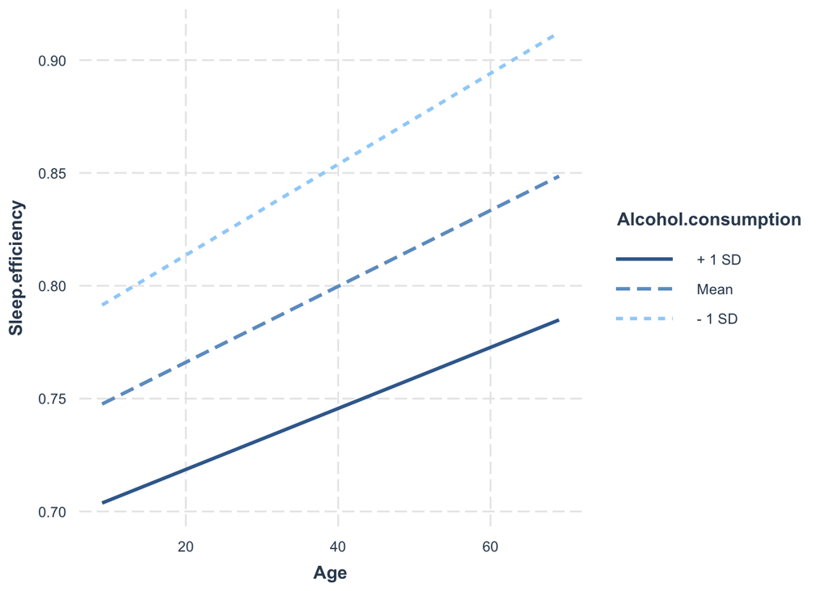

The moderation effect is visualised. The different lines represent different levels of alcohol consumption, while their slope indicates the relationship between age and sleep efficiency. These lines are close to parallel, meaning the interaction effect is small.

The last variable, ‘Age:Alcohol.consumption’ indicates the relationship between age and sleep efficiency decreases as alcohol consumption increases.

Given the earlier findings for age, I performed the analysis again in the 29-59 range.

```
##
## Call:
## lm(formula = Sleep.efficiency ~ Age + Caffeine.consumption +
##     Alcohol.consumption + Exercise.frequency + Gender + Age *
##     Alcohol.consumption, data = Age_selected_data)
##
## Residuals:
##      Min       1Q   Median       3Q      Max
## -0.31252 -0.09549  0.01287  0.09881  0.27005
##
## Coefficients:
##                           Estimate Std. Error t value Pr(>|t|)
## (Intercept)              0.6734344  0.0354011  19.023   <2e-16 ***
## Age                      0.0018412  0.0008357   2.203   0.0296 *
## Caffeine.consumption     0.0007882  0.0004836   1.630   0.1059
## Alcohol.consumption     -0.0124857  0.0158814  -0.786   0.4334
## Exercise.frequency       0.0198006  0.0101506   1.951   0.0536 .
## GenderMale              -0.0018425  0.0287759  -0.064   0.9491
## Age:Alcohol.consumption -0.0005076  0.0004266  -1.190   0.2365
## ---
## Signif. codes:  0 '***' 0.001 '**' 0.01 '*' 0.05 '.' 0.1 ' ' 1
##
## Residual standard error: 0.1279 on 112 degrees of freedom
## Multiple R-squared:  0.1997, Adjusted R-squared:  0.1568
## F-statistic: 4.657 on 6 and 112 DF,  p-value: 0.0002903
```

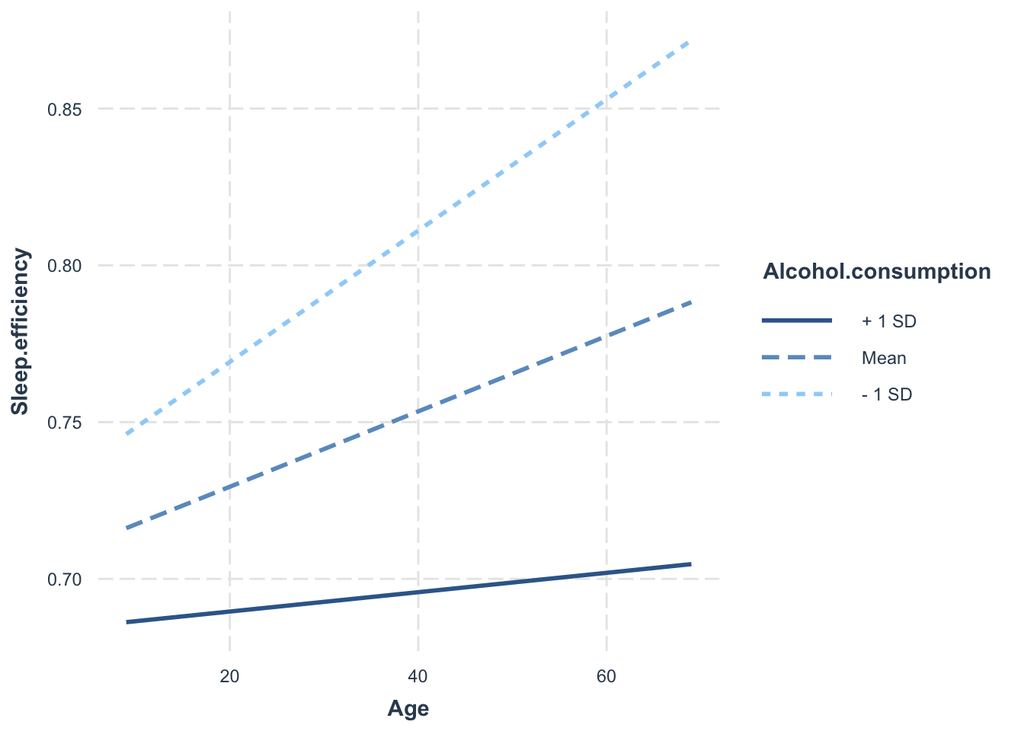

The moderation effect is stronger here, but small.

#### Conclusion:

Using regression, Adrian found a weaker than expected link between age, alcohol consumption and several measures of sleep quality.

#### Citations:

Desjardins, S., Lapierre, S., Hudon, C., & Desgagné, A. (2019). Factors involved in sleep efficiency: a population-based study of community-dwelling elderly persons. Sleep (New York, N.Y.), 42(5), 1-. https://doi.org/10.1093/sleep/zsz038

Equilibrium. (2023). *Sleep efficiency* [Data set]. Kaggle. https://www.kaggle.com/datasets/equilibriumm/sleep-efficiency

Kocevska, D., Lysen, T. S., Dotinga, A., Koopman-Verhoeff, M. E., Luijk, M. P. C. M., Antypa, N., Biermasz, N. R., Blokstra, A., Brug, J., Burk, W. J., Comijs, H. C., Corpeleijn, E., Dashti, H. S., de Bruin, E. J., de Graaf, R., Derks, I. P. M., Dewald-Kaufmann, J. F., Elders, P. J. M., Gemke, R. J. B. J., … Tiemeier, H. (2021). Sleep characteristics across the lifespan in 1.1 million people from the Netherlands, United Kingdom and United States: a systematic review and meta-analysis. Nature Human Behaviour, 5(1), 113–122. https://doi.org/10.1038/s41562-020-00965-x

Library of Congress. (n.d.). *Doing Consumer Research:A Resource Guide/Generations* (https://www.guides.loc.gov/consumer-research/market-segments/generations)

Package citations:

```
##   - Auguie B (2017). _gridExtra: Miscellaneous Functions for "Grid" Graphics_. R package version 2.3, <https://CRAN.R-project.org/package=gridExtra>.
##   - Cheng J, Sievert C, Schloerke B, Chang W, Xie Y, Allen J (2023). _htmltools: Tools for HTML_. R package version 0.5.7, <https://CRAN.R-project.org/package=htmltools>.
##   - Garnier, Simon, Ross, Noam, Rudis, Robert, Camargo, Pedro A, Sciaini, Marco, Scherer, Cédric (2023). _viridis(Lite) - Colorblind-Friendly Color Maps for R_. doi:10.5281/zenodo.4678327 <https://doi.org/10.5281/zenodo.4678327>, viridisLite package version 0.4.2, <https://sjmgarnier.github.io/vi…
##   - Garnier, Simon, Ross, Noam, Rudis, Robert, Camargo, Pedro A, Sciaini, Marco, Scherer, Cédric (2023). _viridis(Lite) - Colorblind-Friendly Color Maps for R_. doi:10.5281/zenodo.4679423 <https://doi.org/10.5281/zenodo.4679423>, viridis package version 0.6.4, <https://sjmgarnier.github.io/viridi…
##   - Long JA (2019). _interactions: Comprehensive, User-Friendly Toolkit for Probing Interactions_. R package version 1.1.0, <https://cran.r-project.org/package=interactions>.
##   - Makowski D, Lüdecke D, Patil I, Thériault R, Ben-Shachar M, Wiernik B (2023). "Automated Results Reporting as a Practical Tool to Improve Reproducibility and Methodological Best Practices Adoption." _CRAN_. <https://easystats.github.io/report/>.
##   - Neuwirth E (2022). _RColorBrewer: ColorBrewer Palettes_. R package version 1.1-3, <https://CRAN.R-project.org/package=RColorBrewer>.
##   - R Core Team (2023). _R: A Language and Environment for Statistical Computing_. R Foundation for Statistical Computing, Vienna, Austria. <https://www.R-project.org/>.
##   - Wickham H (2016). _ggplot2: Elegant Graphics for Data Analysis_. Springer-Verlag New York. ISBN 978-3-319-24277-4, <https://ggplot2.tidyverse.org>.
##   - Wickham H, François R, Henry L, Müller K, Vaughan D (2023). _dplyr: A Grammar of Data Manipulation_. R package version 1.1.4, <https://CRAN.R-project.org/package=dplyr>.
##   - Wickham H, Pedersen T, Seidel D (2023). _scales: Scale Functions for Visualization_. R package version 1.3.0, <https://CRAN.R-project.org/package=scales>.
##   - Wickham H, Vaughan D, Girlich M (2023). _tidyr: Tidy Messy Data_. R package version 1.3.0, <https://CRAN.R-project.org/package=tidyr>.
##   - Xie Y (2023). _knitr: A General-Purpose Package for Dynamic Report Generation in R_. R package version 1.45, <https://yihui.org/knitr/>. Xie Y (2015). _Dynamic Documents with R and knitr_, 2nd edition. Chapman and Hall/CRC, Boca Raton, Florida. ISBN 978-1498716963, <https://yihui.org/knitr/>.…
##   - Zhu H (2024). _kableExtra: Construct Complex Table with 'kable' and Pipe Syntax_. R package version 1.4.0, <https://CRAN.R-project.org/package=kableExtra>.
```